# Utilizing High Energy Ridges for Feature Engineering Convolutional Neural Networks for Voice Recognition (Work in Progress)

# Evaluation of Models

[output not shown]

[figure not shown]

## Spectrograms with ridges = 0

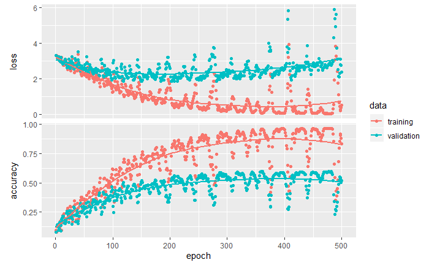

No Ridge Data Model

Here we see that the accuracy of the validation data levels off at roughly the 55% accuracy.

#Appendix

Here is the link to the TensorFlow Speech Recognition Challenge: https://www.kaggle.com/c/tensorflow-speech-recognition-challenge

The labels (l_1,l_2,…l_31) are the words: bed, bird, cat, dog, down, eight, five, four, go, happy, house, left, marvin, nine, no, off, on, one, right, seven, Sheila, six, stop, three, tree, two, up, wow, yes, zero, and ‘none of the above’

Description from the Kaggle competition:

But, for independent makers and entrepreneurs, it’s hard to build a simple speech detector using free, open data and code. Many voice recognition datasets require preprocessing before a neural network model can be built on them. To help with this, TensorFlow recently released the Speech Commands Datasets. It includes 65,000 one-second long utterances of 30 short words, by thousands of different people. In this competition, you’re challenged to use the Speech Commands Dataset to build an algorithm that understands simple spoken commands. By improving the recognition accuracy of open-sourced voice interface tools, we can improve product effectiveness and their accessibility.

## Code

The code is below for reproducibility:

```r
training_list = readLines(file.path("c:", "Users", "Meera Dugar", "Desktop", "Research", "Speech", "train", "testing_list.txt"))

bed_train = grep("^bed", training_list, value = TRUE)
bird_train = grep("^bird", training_list, value = TRUE)
cat_train = grep("^cat", training_list, value = TRUE)
dog_train = grep("^dog", training_list, value = TRUE)
down_train = grep("^down", training_list, value = TRUE)
eight_train = grep("^eight", training_list, value = TRUE)
five_train = grep("^five", training_list, value = TRUE)
four_train = grep("^four", training_list, value = TRUE)
go_train = grep("^go", training_list, value = TRUE)
happy_train = grep("^happy", training_list, value = TRUE)
house_train = grep("^house", training_list, value = TRUE)
left_train = grep("^left", training_list, value = TRUE)
marvin_train = grep("^marvin", training_list, value = TRUE)
nine_train = grep("^nine", training_list, value = TRUE)
no_train = grep("^no", training_list, value = TRUE)
off_train = grep("^off", training_list, value = TRUE)
on_train = grep("^on", training_list, value = TRUE)
one_train = grep("^one", training_list, value = TRUE)
right_train = grep("^right", training_list, value = TRUE)
seven_train = grep("^seven", training_list, value = TRUE)
sheila_train = grep("^sheila", training_list, value = TRUE)
six_train = grep("^six", training_list, value = TRUE)
stop_train = grep("^stop", training_list, value = TRUE)
three_train = grep("^three", training_list, value = TRUE)
tree_train = grep("^tree", training_list, value = TRUE)
two_train = grep("^two", training_list, value = TRUE)
up_train = grep("^up", training_list, value = TRUE)
wow_train = grep("^wow", training_list, value = TRUE)
yes_train = grep("^yes", training_list, value = TRUE)
zero_train = grep("^zero", training_list, value = TRUE)

train_words = c(bed_train,bird_train, cat_train, dog_train, down_train, eight_train, five_train, four_train, go_train, happy_train, house_train, left_train, marvin_train, nine_train, no_train, off_train, on_train,one_train  ,right_train,seven_train, sheila_train,six_train,stop_train, three_train, tree_train, two_train,up_train,wow_train,yes_train, zero_train)

train_labels = c(rep(1, length(bed_train)), rep(2, length(bird_train)), rep(3, length(cat_train)), rep(4, length(dog_train)), rep(5, length(down_train)), rep(6, length(eight_train)), rep(7, length(five_train)), rep(8, length(four_train)), rep(9, length(go_train)), rep(10, length(happy_train)), rep(11, length(house_train)), rep(12, length(left_train)), rep(13, length(marvin_train)), rep(14, length(nine_train)), rep(15, length(no_train)), rep(16, length(off_train)), rep(17, length(on_train)), rep(18, length(one_train)), rep(19, length(right_train)), rep(20, length(seven_train)), rep(21, length(sheila_train)), rep(22, length(six_train)), rep(23, length(stop_train)), rep(24, length(three_train)), rep(25, length(tree_train)), rep(26, length(two_train)), rep(27, length(up_train)), rep(28, length(wow_train)), rep(29, length(yes_train)), rep(30, length(zero_train)))

train_data = array(dim = c(7083, 198, 40))
train_data2 = array(dim = c(7083, 198, 40))

validation_list = readLines(file.path("c:", "Users", "Meera Dugar", "Desktop", "Research", "Speech", "train", "validation_list.txt"))

bed_validation = grep("^bed", validation_list, value = TRUE)
bird_validation = grep("^bird", validation_list, value = TRUE)
cat_validation = grep("^cat", validation_list, value = TRUE)
dog_validation = grep("^dog", validation_list, value = TRUE)
down_validation = grep("^down", validation_list, value = TRUE)
eight_validation = grep("^eight", validation_list, value = TRUE)
five_validation = grep("^five", validation_list, value = TRUE)
four_validation = grep("^four", validation_list, value = TRUE)
go_validation = grep("^go", validation_list, value = TRUE)
happy_validation = grep("^happy", validation_list, value = TRUE)
house_validation = grep("^house", validation_list, value = TRUE)
left_validation = grep("^left", validation_list, value = TRUE)
marvin_validation = grep("^marvin", validation_list, value = TRUE)
nine_validation = grep("^nine", validation_list, value = TRUE)
no_validation = grep("^no", validation_list, value = TRUE)
off_validation = grep("^off", validation_list, value = TRUE)
on_validation = grep("^on", validation_list, value = TRUE)
one_validation = grep("^one", validation_list, value = TRUE)
right_validation = grep("^right", validation_list, value = TRUE)
seven_validation = grep("^seven", validation_list, value = TRUE)
sheila_validation = grep("^sheila", validation_list, value = TRUE)
six_validation = grep("^six", validation_list, value = TRUE)
stop_validation = grep("^stop", validation_list, value = TRUE)
three_validation = grep("^three", validation_list, value = TRUE)
tree_validation = grep("^tree", validation_list, value = TRUE)
two_validation = grep("^two", validation_list, value = TRUE)
up_validation = grep("^up", validation_list, value = TRUE)
wow_validation = grep("^wow", validation_list, value = TRUE)
yes_validation = grep("^yes", validation_list, value = TRUE)
zero_validation = grep("^zero", validation_list, value = TRUE)

validation_words = c(bed_validation,bird_validation, cat_validation, dog_validation, down_validation, eight_validation, five_validation, four_validation, go_validation, happy_validation, house_validation, left_validation, marvin_validation, nine_validation, no_validation, off_validation, on_validation,one_validation  ,right_validation,seven_validation, sheila_validation,six_validation,stop_validation, three_validation, tree_validation, two_validation,up_validation,wow_validation,yes_validation, zero_validation)

validation_labels = c(rep(1, length(bed_validation)), rep(2, length(bird_validation)), rep(3, length(cat_validation)), rep(4, length(dog_validation)), rep(5, length(down_validation)), rep(6, length(eight_validation)), rep(7, length(five_validation)), rep(8, length(four_validation)), rep(9, length(go_validation)), rep(10, length(happy_validation)), rep(11, length(house_validation)), rep(12, length(left_validation)), rep(13, length(marvin_validation)), rep(14, length(nine_validation)), rep(15, length(no_validation)), rep(16, length(off_validation)), rep(17, length(on_validation)), rep(18, length(one_validation)), rep(19, length(right_validation)), rep(20, length(seven_validation)), rep(21, length(sheila_validation)), rep(22, length(six_validation)), rep(23, length(stop_validation)), rep(24, length(three_validation)), rep(25, length(tree_validation)), rep(26, length(two_validation)), rep(27, length(up_validation)), rep(28, length(wow_validation)), rep(29, length(yes_validation)), rep(30, length(zero_validation)))

validation_data = array(dim = c(7028, 198, 40))
validation_data2 = array(dim = c(7028, 198, 40))
```

```r
# Code to generate spectrographs
snd = rep(0, 16000)
for (i in bed_train){
  fin = file.path("c:", "Users", "Meera Dugar", "Desktop", "Research", "Speech", "train", "audio", i)
  # read in audio file

  data = readWave(fin)
  #data = data + temp

  # extract signal
  temp = data@left

  snd = snd + temp

}

# determine duration
dur = length(snd)/data@samp.rate

# determine sample rate
fs = data@samp.rate

start = which(snd > 0.1)[1]
end = length(snd) - which(rev(snd) > 0.1)[1]

snd = snd[start:end]

t = seq(1,16000, length.out = length(snd)) #upsampling
f <- approxfun(t, snd)
snd = f(seq(1,16000,1))

# demean to remove offset
snd = snd - mean(snd)

# plot waveform
plot(snd, type = 'l', xlab = 'Samples', ylab = 'Amplitude')

# number of points to use for the fft
nfft=160

# window size (in points)
window=160

# overlap (in points)
overlap=80

# create spectrogram
spec = specgram(x = snd,
                n = nfft,
                Fs = fs,
                window = window,
                overlap = overlap
)


# discard phase information
S = abs(spec$S)

# normalize
S = S/max(S)

# convert to dB
S = 20*log10(S)

# clip below -40 dB
S[S < -40] <- -40

# clip above -3 dB
S[S > -3] <- -3

# config time axis
t = spec$t

# plot spectrogram
# imagep(x = spec$t,
#        y = spec$f[1:40],
#        z = t(S)[,1:40],
#        col = oce.colorsViridis,
#        ylab = 'Frequency [Hz]',
#        xlab = 'Time [s]',
#        drawPalette = T,
#        decimate = F
# )
```

```r
### Penalized spectrograms

tfridge1 <- function(freqtimemat, ridges = 1, cost = 2, distmetric = 2){

  ridgepos = freqtimemat
  columns = 1:ncol(freqtimemat)
  rows = matrix(data = 0, nrow = ridges, ncol = ncol(freqtimemat))

  for (i in 2:ncol(freqtimemat)){
    for (j in 1:nrow(freqtimemat)){
      values = c()
      for (k in 1:nrow(freqtimemat)){
        values = c(values, freqtimemat[k, i-1] + cost*((abs(j-k)^distmetric)))
      }
      freqtimemat[j, i] = min(values) + freqtimemat[j, i]
      ridgepos[j, i] = which.min(values)
    }
  }

  colnames(freqtimemat) <- NULL
  return(freqtimemat)
}
```

```r
### extraction of maximum-energy ridge using a penalized forward-backward greedy algorithm

tfridge2 <- function(freqtimemat, ridges = 1, cost = 2, distmetric = 2){

  ridgepos = freqtimemat
  columns = 1:ncol(freqtimemat)
  rows = matrix(data = 0, nrow = ridges, ncol = ncol(freqtimemat))

  for (i in 2:ncol(freqtimemat)){
    for (j in 1:nrow(freqtimemat)){
      values = c()
      for (k in 1:nrow(freqtimemat)){
        values = c(values, freqtimemat[k, i-1] + cost*((abs(j-k)^distmetric)))
      }
      freqtimemat[j, i] = min(values) + freqtimemat[j, i]
      ridgepos[j, i] = which.min(values)
    }
  }


  for (i in 1:ridges){
    start_ridges = sort(which(freqtimemat[,ncol(freqtimemat)]==min(ncol(freqtimemat))), decreasing = T)[1:i]

  }


  # for (i in 1:ridges){
  #   rows[i, ncol(freqtimemat)] = which(freqtimemat[,ncol(freqtimemat)] == sort(freqtimemat[,ncol(freqtimemat)])[i])[1]
  # }
  #
  # for (i in 1:(ncol(freqtimemat)-1)){
  #    for (j in 1:ridges){
  #
  #       backtrack_val = ridgepos[rows[j, ncol(freqtimemat) - i + 1], ncol(freqtimemat) - i]
  #
  #       if (j > 2){
  #
  #       #if(backtrack_val == rows[j-1, ncol(freqtimemat) - i]){
  #       if(backtrack_val %in% rows[, ncol(freqtimemat) - i]){
  #         rows[j, ncol(freqtimemat) - i] = rows[j, ncol(freqtimemat) - i + 1]
  #
  #       }
  #
  #       else{
  #         rows[j, ncol(freqtimemat) - i] = backtrack_val
  #       }
  #     }
  #       # rows[j, ncol(freqtimemat) - i] = ridgepos[rows[j, ncol(freqtimemat) - i + 1], ncol(freqtimemat) - i]
  #    }
  #  }
  #
  freqtimemat2 = matrix(data = 0, ncol = ncol(freqtimemat), nrow = nrow(freqtimemat))
  #
  #  for (i in 1:ncol(freqtimemat)) {
  #    for (j in 1:ridges){
  #       freqtimemat2[rows[j,i], columns[i]] = freqtimemat[rows[j,i], columns[i]] + 1
  #    }
  # }
  colnames(ridgepos) <- NULL
  return(ridgepos)
  # return(rows)
}
```

```r
for (i in 1:length(train_words)){
  fin = file.path("c:", "Users", "Meera Dugar", "Desktop", "Research", "Speech", "train", "audio", train_words[i])

  # read in audio file
  data = readWave(fin)
  # extract signal
  snd = data@left
  # determine sample rate
  fs = data@samp.rate
  # demean to remove DC offset
  snd = (snd - mean(snd))


  snd = snd/max(snd)

  start = which(snd > 0.1)[1]
  end = length(snd) - which(rev(snd) > 0.1)[1]

  snd = snd[start:end]

  t = seq(1,16000, length.out = length(snd)) #upsampling
  f <- approxfun(t, snd)
  snd = f(seq(1,16000,1))

# number of points to use for the fft
nfft=160

# window size (in points)
window=160

# overlap (in points)
overlap=80

# create spectrogram
spec = specgram(x = snd,
                n = nfft,
                Fs = fs,
                window = window,
                overlap = overlap
)


# discard phase information
S = abs(spec$S)

# normalize
S = S/max(S)

# convert to dB
S = 20*log10(S)

# clip below -40 dB
S[S < -40] <- -40

# clip above -3 dB
S[S > -3] <- -3

S = (S+40)/37

# config time axis
t = spec$t

train_data[i,,] = t(S)[,1:40]
}
```

```r
for (i in 1:length(validation_words)){
  fin = file.path("c:", "Users", "Meera Dugar", "Desktop", "Research", "Speech", "train", "audio", validation_words[i])

  # read in audio file
  data = readWave(fin)
  # extract signal
  snd = data@left
  # determine sample rate
  fs = data@samp.rate
  # demean to remove DC offset
  snd = (snd - mean(snd))


  snd = snd/max(snd)

  start = which(snd > 0.1)[1]
  end = length(snd) - which(rev(snd) > 0.1)[1]

  snd = snd[start:end]

  t = seq(1,16000, length.out = length(snd)) #upsampling
  f <- approxfun(t, snd)
  snd = f(seq(1,16000,1))

# number of points to use for the fft
nfft=160

# window size (in points)
window=160

# overlap (in points)
overlap=80

# create spectrogram
spec = specgram(x = snd,
                n = nfft,
                Fs = fs,
                window = window,
                overlap = overlap
)


# discard phase information
S = abs(spec$S)

# normalize
S = S/max(S)

# convert to dB
S = 20*log10(S)

# clip below -40 dB
S[S < -40] <- -40

# clip above -3 dB
S[S > -3] <- -3

S = (S+40)/37


# config time axis
t = spec$t

validation_data[i,,] = t(S)[,1:40]
}
```

```r
for (i in 1:length(train_words)){
  train_data2[i,,] = tfridge(train_data[i,,], ridges = 1, cost = 2, distmetric = 2)
}
for (i in 1:length(validation_words)){
  validation_data2[i,,] = tfridge(validation_data[i,,], ridges = 1, cost = 2, distmetric = 2)
}
```

```r
network <- keras_model_sequential() %>%
  layer_dense(units = 198*40, activation = "relu", input_shape = c(198*40)) %>%
  layer_dense(units = 1024, activation = "relu") %>%
  layer_dense(units = 512, activation = "relu") %>%
  layer_dense(units = 256, activation = "relu") %>%
  layer_dense(units = 31, activation = "softmax")
```

```r
network %>% compile(
  optimizer = "rmsprop",
  loss = "categorical_crossentropy",
  metrics = c("accuracy")
)
```

```r
train_data_new <- array_reshape(train_data, c(7083, 198*40))
train_labels_new = to_categorical(train_labels)
validation_data_new <- array_reshape(validation_data, c(7028, 198*40))
validation_labels_new = to_categorical(validation_labels)
```

```r
history <- network %>% fit(
  train_data_new,
  train_labels_new,
  epochs = 500,
  batch_size = 7083,
  validation_data = list(validation_data_new, validation_labels_new)
)
```

```r
history2 <- network %>% fit(
  train_data_new2,
  train_labels_new2,
  epochs = 500,
  batch_size = 7083,
  validation_data = list(validation_data_new2, validation_labels_new2)
)
```

```r
# bed_train_data = array(dim = c(176, 123, 128))
#
# for (i in 1:(length(bed_train)-136)){
#   fin = file.path("c:", "Users", "Meera Dugar", "Desktop", "Research", "Speech", "train", "audio", bed_train[i])
#
#   # read in audio file
#   data = readWave(fin)
#   # extract signal
#   snd = data@left
#   # determine sample rate
#   fs = data@samp.rate
#   # demean to remove DC offset
#   snd = (snd - mean(snd))
#
#   snd = preemphasis(snd, f = fs, alpha = 0.97)
#
#   snd = snd/max(snd)
#
#   start = which(snd > 0.1)[1]
#   end = length(snd) - which(rev(snd) > 0.1)[1]
#
#   snd = snd[start:end]
#
#   t = seq(1,16000, length.out = length(snd))
#   f <- approxfun(t, snd)
#   snd = f(seq(1,16000,1))
#
#   #plot(snd, type = "l", col = "red")
#
# # number of points to use for the fft
# nfft=1024
#
# # window size (in points)
# window=256
#
# # overlap (in points)
# overlap=128
#
# # create spectrogram
# spec = specgram(x = snd,
#                 n = nfft,
#                 Fs = fs,
#                 window = window,
#                 overlap = overlap
# )
#
# # frequency in range 0<f<=4000 Hz.
# spec$f = spec$f[1:128]
#
# # discard phase information
# P = abs(spec$S)
#
# # normalize
# P = P/max(P)
#
# # convert to dB
# P = 10*log10(P)
#
# P[P < -17] <- -17  # clip below -40 dB.
# P[P > -3] <- -3      # clip above -3 dB.
#
# P = (P+17)/14 # Min-Max Normalization for the Neural Network
#
# bed_train_data[i,,] = t(P)[,1:128]
# # plot spectrogram
#
# # imagep(x = t,
# #        y = spec$f,
# #        z = t(P),
# #        col = oce.colorsViridis,
# #
# #        ylab = 'Frequency [Hz]',
# #        xlab = 'Time [s]',
# #        drawPalette = T,
# #        decimate = F
# # )
#
# #plot(abs(fft(snd))[1:8000], type = "l")
#
# imagep(x = spec$t,
#        y = spec$f,
#        z = t(tfridge(P[1:128,], ridges = 30, cost = 2, distmetric = 1.5)),
#        #col = oce.colorsViridis,
#        ylab = 'Frequency [Hz]',
#        xlab = 'Time [s]',
#        drawPalette = T,
#        decimate = F
# )
#
# }
#
```

```r
# bed_ridge_data = bed_train_data
#
#
# for (i in 1:176){
#   for (j in 1:123){
#     for (k in 1:128){
#       bed_ridge_data[i, j, k] = ifelse(bed_ridge_data[i, j, k] < max(bed_ridge_data[i,j,])/2, 0, bed_ridge_data[i, j, k])
#
#     }
#   }
# }
# for (i in 1:60){
#        imagep(x = spec$t,
#        y = spec$f,
#        z = bed_ridge_data[i,,],
#        col = oce.colorsViridis,
#        ylab = 'Frequency [Hz]',
#        xlab = 'Time [s]',
#        drawPalette = T,
#        decimate = F
# )
# }
```

# References

[1] Becker, R. A., Chambers, J. M. and Wilks, A. R. (1988) The New S Language. Wadsworth & Brooks/Cole. Hinton, Geoffrey. “Overview of mini-batch gradient descent” (PDF). pp. 27–29. Retrieved 27 September 2016.

[2] In Wireless Engineer (also called Experimental Wireless and the Wireless Engineer), vol. 7, 1930, pp. 536–541 – “On the Theory of Filter Amplifiers”, S. Butterworth

[3] Titze, I.R. (1994). Principles of Voice Production, Prentice Hall, ISBN 978-0-13-717893-3.

[4] Daubechies, I., J. Lu, and H.-T. Wu. “Synchrosqueezed wavelet transforms: an empirical mode decomposition-like tool.” Applied and Computational Harmonic Analysis. Vol. 30, Number 2, 2011, pp. 243–261.

[5] Thakur, G., E. Brevdo, N. S. Fučkar, and H.-T. Wu. “The Synchrosqueezing algorithm for time-varying spectral analysis: Robustness properties and new paleoclimate applications.” Signal Processing. Vol. 93, Number 4, 2013, pp. 1079–1094.